# RNAseq +/- GSKJ4, MutGSKJ4 vs MutDMSO

Christine Gao

3/10/2023

Load dds object.

```r
load(file='dds_collapsed_GSKJ4.rda')
```

Set contrast for comparing MutGSKJ4 vs MutDMSO.

```r
mod_mat <- model.matrix(design(dds), colData(dds))
res.MutGSKJ4.MutDMSO <- results(dds, contrast = list(c('tx_GSKJ4_vs_DMSO',
                                      'genotypeMut.txGSKJ4')))
```

Plot p-value histogram.

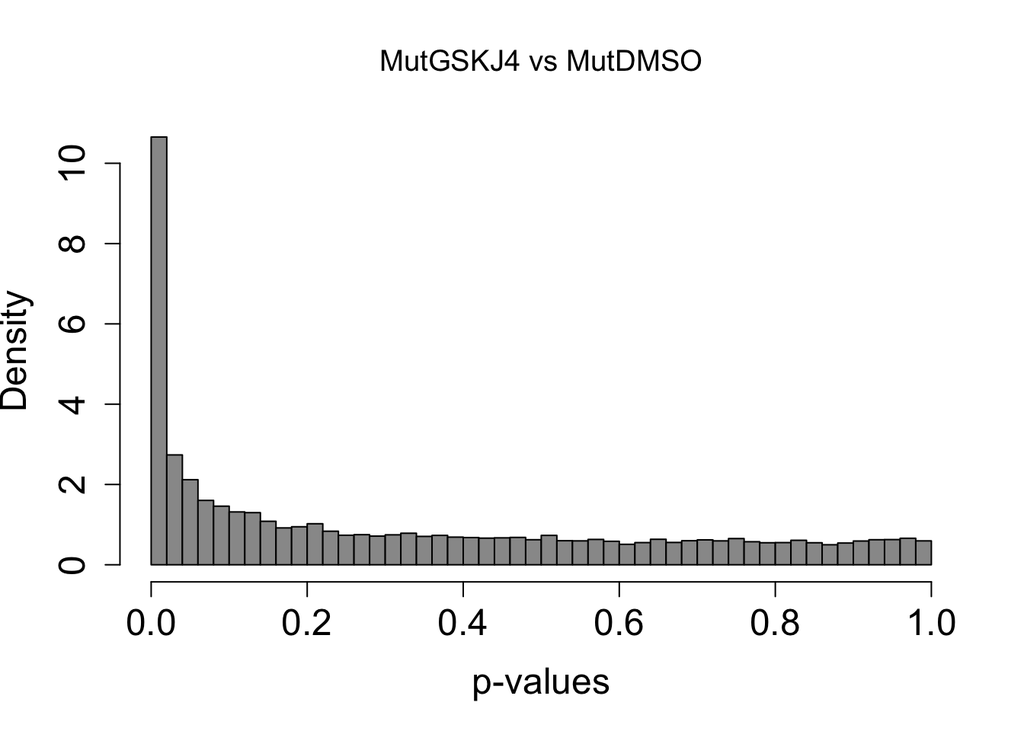

```r
hist(res.MutGSKJ4.MutDMSO$pvalue,
     freq=FALSE,
     breaks = 40,
     #ylim = c(0, 3),
     col = 'gray60',
     xlab = "p-values",
     main = "MutGSKJ4 vs MutDMSO",
     font.main = 1,
     cex.axis=1.5,
     cex.lab=1.5)
```

Get list of all differentially expresssed genes.

```r
diffexp.all <- as.data.frame(res.MutGSKJ4.MutDMSO[which(res.MutGSKJ4.MutDMSO$padj < 0.1), ])

ensembl.id <- rownames(diffexp.all)

ensembl102.mmusculus <- useEnsembl(biomart='genes', dataset='mmusculus_gene_ensembl', version=102)
mgi <- getBM(attributes=c('ensembl_gene_id','mgi_symbol','mgi_description'),
             filters='ensembl_gene_id',
             values=ensembl.id,
             mart=ensembl102.mmusculus)
diffexp.all$ensembl_gene_id <- ensembl.id
diffexp.all <- merge(diffexp.all, mgi, by='ensembl_gene_id')
diffexp.all <- diffexp.all[order(diffexp.all$log2FoldChange, decreasing=TRUE),]

write.csv(diffexp.all, file='diffexp_MutGSKJ4-MutDMSO.csv')
```

Find corresponding unadjusted p-value for a threshold of FDR=0.1.

```r
fdr <- res.MutGSKJ4.MutDMSO[which(res.MutGSKJ4.MutDMSO$padj>0.1
                                  & is.na(res.MutGSKJ4.MutDMSO$padj)==FALSE),]
fdr[which(fdr$padj==min(fdr$padj)),]
```

```
## log2 fold change (MLE): tx_GSKJ4_vs_DMSO+genotypeMut.txGSKJ4 effect
## Wald test p-value: tx_GSKJ4_vs_DMSO+genotypeMut.txGSKJ4 effect
## DataFrame with 1 row and 6 columns
##                     baseMean log2FoldChange     lfcSE      stat    pvalue
##                    <numeric>      <numeric> <numeric> <numeric> <numeric>
## ENSMUSG00000047821   817.531       0.263997  0.115514    2.2854 0.0222893
##                         padj
##                    <numeric>
## ENSMUSG00000047821  0.100006
```

Find max -log10(pvalue) to set ylim of plot.

```r
max(-log10(res.MutGSKJ4.MutDMSO$pvalue[which(is.na(res.MutGSKJ4.MutDMSO$pvalue) ==FALSE)]))
```

```
## [1] 31.94206
```

Create volcano plot function, plugging in the threshold p-value and the ylim.

```r
makeVolcanoPlot <- function(DEgenes_df, lfc_cutoff, gene_ids, circ_ids, circ_names, ylim, color){
  tab = data.frame(logFC = DEgenes_df$log2FoldChange, negLogPval = -log10(DEgenes_df$pvalue))
  rownames(tab) <- rownames(DEgenes_df)
  par(mar=c(5,5,5,5))
  plot(tab[-which(rownames(tab) %in% gene_ids), ], pch = 19, cex = 0.75,
       xlab = expression(log[2]~fold~change),
       ylab = expression(-log[10]~pvalue),
       cex.axis=1.5,
       cex.lab=1.5,
       col = "gray60", bty = 'l',
       xlim = c(min(tab$logFC), max(tab$logFC)),
       ylim = c(0, ylim))
  points(tab[gene_ids, ], pch = 19, cex = 0.75, col = color)
  points(tab[circ_ids, ], pch = 1, cex = 1.5, col= 'black')
  # circles(tab[circ_ids, ]$logFC, tab[circ_ids, ]$negLogPval,
  #         r = rep(0.12, length(circ_ids)), col='black')
  text(tab[circ_ids, ]$logFC-0.15, tab[circ_ids, ]$negLogPval,
       labels=circ_names, adj=1, cex = 0.75, col='black')
  abline(h = -log10(0.0222893), col= "red", lty=2, lwd=2)
  # legend <- legend('topleft', legend=c('FDR < 0.1','other'),
  #                  col=c(color,'gray60'), lty=c(NA, NA), pch=c(19,19), lwd=c(NA,NA), cex=1, bty='n')
  # legend <- legend('topright', legend=c('FDR = 0.1'),
  #                  col=c('cornflowerblue'), lty=c(2), pch=c(NA), lwd=c(2), cex=1.25, bty='n')
  if (lfc_cutoff != "none"){
    abline(v = c(-lfc_cutoff, lfc_cutoff), col = rgb(0,0,0,0.75), lty = "longdash", lwd = 1)
  }
}
```

Make volcano plot, highlighting genes with FDR < 0.1. *removed points with padj=NA*

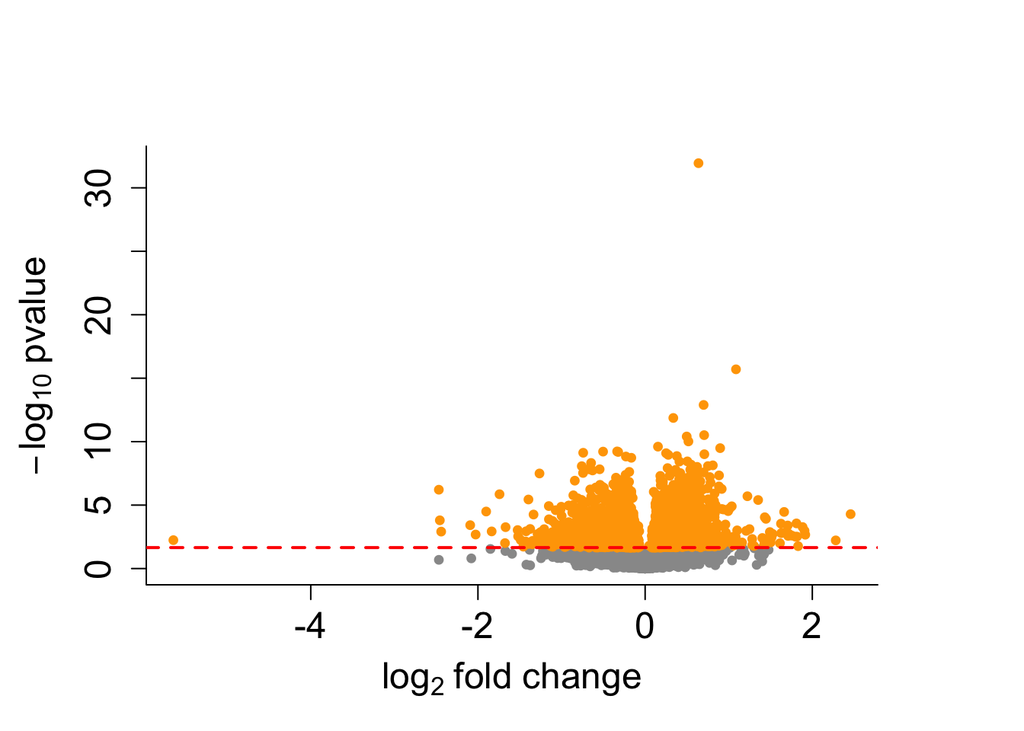

```r
gene_ids <- rownames(res.MutGSKJ4.MutDMSO[which(res.MutGSKJ4.MutDMSO$padj<0.1),])
makeVolcanoPlot(res.MutGSKJ4.MutDMSO[which(is.na(res.MutGSKJ4.MutDMSO$padj)==FALSE),], "none", gene_ids, circ_ids='', circ_names='', ylim=32, "orange")
```

There is an extreme pvalue outlier, which is the point that led to a ylim of 32. Identify that point.

```r
res.MutGSKJ4.MutDMSO[which(res.MutGSKJ4.MutDMSO$pvalue==min(res.MutGSKJ4.MutDMSO$pvalue)),]
```

```
## log2 fold change (MLE): tx_GSKJ4_vs_DMSO+genotypeMut.txGSKJ4 effect
## Wald test p-value: tx_GSKJ4_vs_DMSO+genotypeMut.txGSKJ4 effect
## DataFrame with 1 row and 6 columns
##                     baseMean log2FoldChange     lfcSE      stat      pvalue
##                    <numeric>      <numeric> <numeric> <numeric>   <numeric>
## ENSMUSG00000024190   5045.78       0.638542 0.0536458   11.9029 1.14272e-32
##                           padj
##                      <numeric>
## ENSMUSG00000024190 1.56222e-28
```

Check counts for ENSMUSG00000024190, which is Dusp1, dual specificity phosphatase 1.

```r
counts(dds)['ENSMUSG00000024190', which(dds$genotype=='Mut' & dds$tx=='DMSO')]
```

```
##  615  622  627  636  638  648
## 2985 4037 3699 3618 4035 3026
```

```r
counts(dds)['ENSMUSG00000024190', which(dds$genotype=='Mut' & dds$tx=='GSKJ4')]
```

```
## 615_tx 622_tx 627_tx 636_tx 638_tx 648_tx
##   5883   6245   6081   6111   9176   4583
```

There is also a log2FC outlier. Identify that point.

```r
res.MutGSKJ4.MutDMSO[which(res.MutGSKJ4.MutDMSO$log2FoldChange==min(res.MutGSKJ4.MutDMSO$log2FoldChange)),]
```

```
## log2 fold change (MLE): tx_GSKJ4_vs_DMSO+genotypeMut.txGSKJ4 effect
## Wald test p-value: tx_GSKJ4_vs_DMSO+genotypeMut.txGSKJ4 effect
## DataFrame with 1 row and 6 columns
##                     baseMean log2FoldChange     lfcSE      stat     pvalue
##                    <numeric>      <numeric> <numeric> <numeric>  <numeric>
## ENSMUSG00000092345   50.7091       -5.64347   2.04433  -2.76055 0.00577045
##                         padj
##                    <numeric>
## ENSMUSG00000092345 0.0390727
```

Check counts for ENSMUSG00000092345, which is Gm20503, or predicted gene 20503.

```r
counts(dds)['ENSMUSG00000092345', which(dds$genotype=='Mut' & dds$tx=='DMSO')]
```

```
## 615 622 627 636 638 648
## 129  87 167 134 133  23
```

```r
counts(dds)['ENSMUSG00000092345', which(dds$genotype=='Mut' & dds$tx=='GSKJ4')]
```

```
## 615_tx 622_tx 627_tx 636_tx 638_tx 648_tx
##      0      0     21     99     29      0
```

By ignoring the pvalue outliers, it becomes apparent that some points that meet FDR cutoff are not being color-marked appropriately.

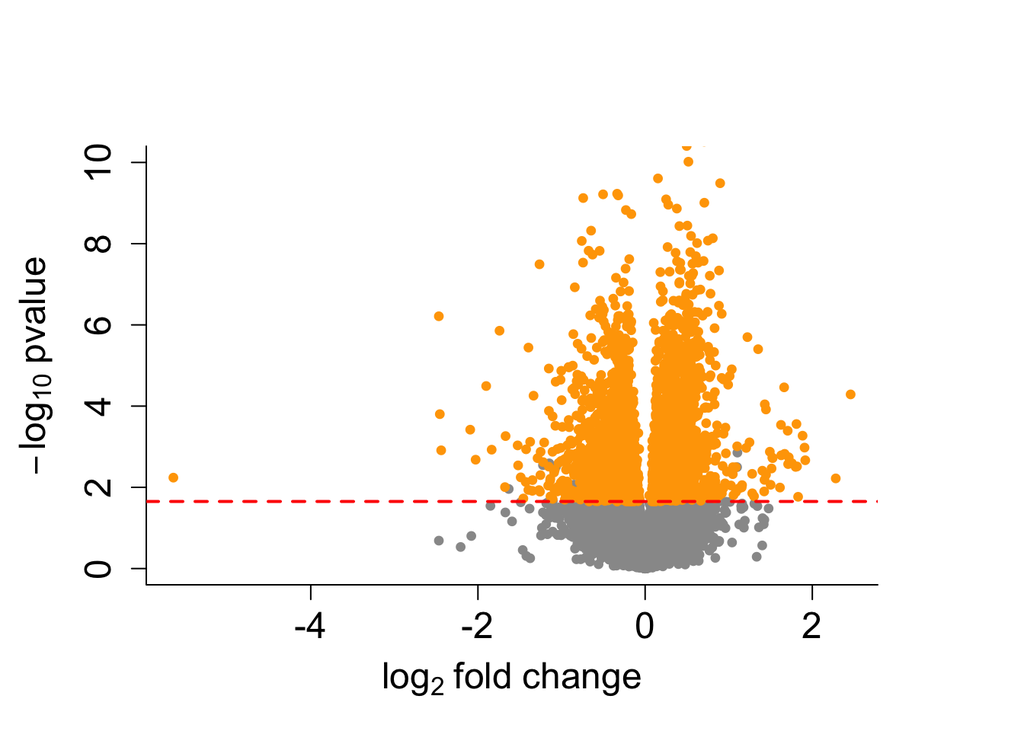

```r
makeVolcanoPlot(res.MutGSKJ4.MutDMSO, "none", gene_ids, circ_ids='', circ_names='', ylim=10, "orange")
```

To find out which points and why:

```r
nrow(res.MutGSKJ4.MutDMSO[which(res.MutGSKJ4.MutDMSO$padj < 0.1),])
```

```
## [1] 3046
```

```r
nrow(res.MutGSKJ4.MutDMSO[which(res.MutGSKJ4.MutDMSO$pvalue <= 0.0222893),])
```

```
## [1] 3059
```

There is discrepancy between the number of genes meeting the padj cutoff and those meeting the corresponding pvalue cutoff. Find out which genes are missing.

```r
data.frame(res.MutGSKJ4.MutDMSO[which(res.MutGSKJ4.MutDMSO$pvalue < 0.0222893 &
                             !(rownames(res.MutGSKJ4.MutDMSO) %in% gene_ids)),])
```

```
##                     baseMean log2FoldChange     lfcSE      stat      pvalue
## ENSMUSG00000021303  15.15188     -1.1043386 0.4806616 -2.297539 0.021588066
## ENSMUSG00000029075  12.30566      0.9101654 0.3975726  2.289306 0.022061580
## ENSMUSG00000036030  13.08588     -0.8045621 0.3476831 -2.314067 0.020664021
## ENSMUSG00000040432  15.29579     -1.1467317 0.3802466 -3.015758 0.002563379
## ENSMUSG00000045912  14.63490     -1.2220508 0.4094846 -2.984363 0.002841690
## ENSMUSG00000047671  12.93502      1.0998653 0.3728495  2.949891 0.003178860
## ENSMUSG00000047821 817.53123      0.2639967 0.1155144  2.285402 0.022289293
## ENSMUSG00000047990  14.80966     -0.8487964 0.3230042 -2.627819 0.008593433
## ENSMUSG00000071324  14.43436     -1.0658451 0.3601825 -2.959181 0.003084580
## ENSMUSG00000093847  13.45808     -1.6316571 0.6414579 -2.543670 0.010969476
## ENSMUSG00000095258  13.10048     -0.8935309 0.3743504 -2.386884 0.016991863
## ENSMUSG00000099655  10.90042     -0.8694036 0.3758405 -2.313225 0.020710279
## ENSMUSG00000109713  14.48340      1.1038611 0.3454407  3.195515 0.001395814
##                         padj
## ENSMUSG00000021303        NA
## ENSMUSG00000029075        NA
## ENSMUSG00000036030        NA
## ENSMUSG00000040432        NA
## ENSMUSG00000045912        NA
## ENSMUSG00000047671        NA
## ENSMUSG00000047821 0.1000056
## ENSMUSG00000047990        NA
## ENSMUSG00000071324        NA
## ENSMUSG00000093847        NA
## ENSMUSG00000095258        NA
## ENSMUSG00000099655        NA
## ENSMUSG00000109713        NA
```

```r
metadata(res.MutGSKJ4.MutDMSO)$alpha
```

```
## [1] 0.1
```

```r
metadata(res.MutGSKJ4.MutDMSO)$filterThreshold
```

```
## 1.938776%
##  15.35771
```

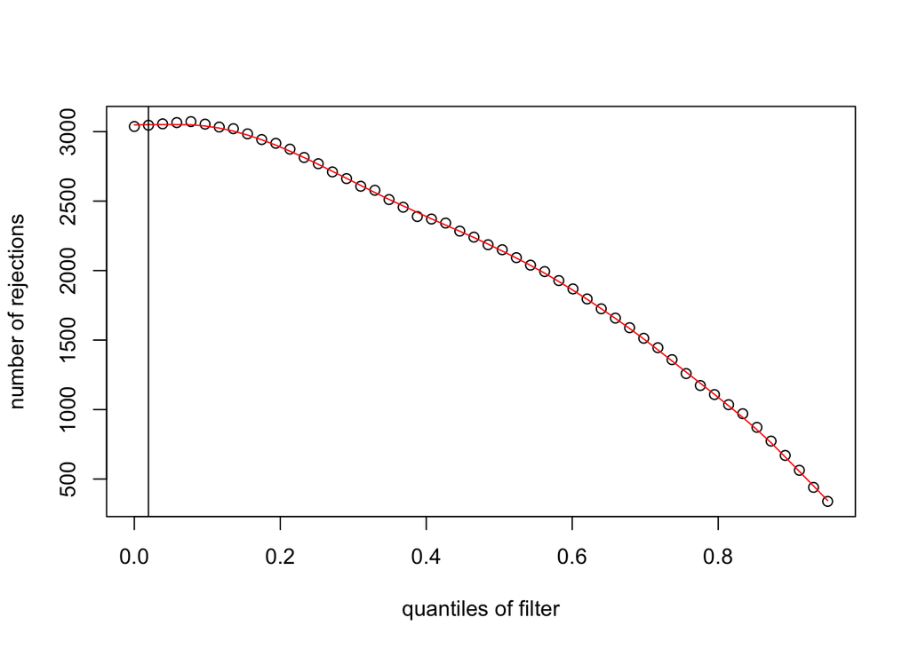

```r
plot(metadata(res.MutGSKJ4.MutDMSO)$filterNumRej,
     type="b", ylab="number of rejections",
     xlab="quantiles of filter")
lines(metadata(res.MutGSKJ4.MutDMSO)$lo.fit, col="red")
abline(v=metadata(res.MutGSKJ4.MutDMSO)$filterTheta)
```

Make a volcano plot marking the Bmp pathway genes, in particular the 5 genes of interest. Almost all Bmp pathway genes are downregulated upon GSKJ4 treatment.

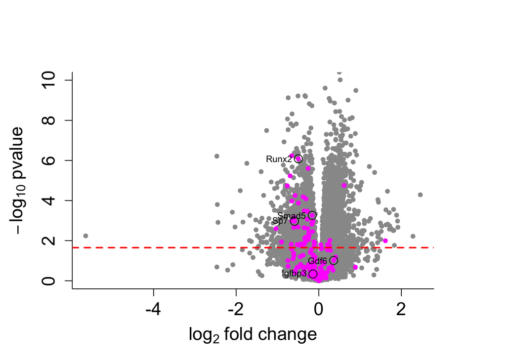

```r
load(file='gene_ids_bmp.rda')
gene_ids.bmp <- gene_ids
circ_ids <- c('ENSMUSG00000051279',
              'ENSMUSG00000020427',
              'ENSMUSG00000021540',
              'ENSMUSG00000039153',
              'ENSMUSG00000060284')
circ_names <- c('Gdf6',
                'Igfbp3',
                'Smad5',
                'Runx2',
                'Sp7')
makeVolcanoPlot(res.MutGSKJ4.MutDMSO, "none", gene_ids, circ_ids, circ_names, ylim=10, "magenta")
```

Get the list of differentially expressed Bmp pathway genes.

```r
diffexp.bmp <- as.data.frame(res.MutGSKJ4.MutDMSO[which(res.MutGSKJ4.MutDMSO$padj < 0.1 &
                                            rownames(res.MutGSKJ4.MutDMSO) %in% gene_ids.bmp),])
ensembl.id <- rownames(diffexp.bmp)

ensembl102.mmusculus <- useEnsembl(biomart='genes', dataset='mmusculus_gene_ensembl', version=102)
mgi <- getBM(attributes=c('ensembl_gene_id','mgi_symbol','mgi_description'),
             filters='ensembl_gene_id',
             values=ensembl.id,
             mart=ensembl102.mmusculus)
diffexp.bmp$ensembl_gene_id <- ensembl.id
diffexp.bmp <- merge(diffexp.bmp, mgi, by='ensembl_gene_id')
diffexp.bmp <- diffexp.bmp[order(diffexp.bmp$log2FoldChange, decreasing=TRUE),]
write.csv(diffexp.bmp, file='diffexp_MutGSKJ4-MutDMSO_Bmp.csv')
```